[@drsimonj](https://twitter.com/drsimonj) here to do some tidy machine learning in R!

## Background

*WARNING: Only read this section if you like a good rant. Otherwise, go to “Getting Started” for the technical stuff.*

Combining the [tidyverse](http://tidyverse.org/) with machine learning/modelling is desirable, doable, but a bit of a headache. My first solution to this problem was pipelearner. I’ve now done a few posts about it like the [intro to pipelearner](https://drsimonj.svbtle.com/easy-machine-learning-pipelines-with-pipelearner-intro-and-call-for-contributors), how to do [grid search](https://drsimonj.svbtle.com/how-to-grid-search-with-pipelearner) and [leave-one-out cross validation](https://drsimonj.svbtle.com/easy-leave-one-out-cross-validation-with-pipelearner), and how to [combine pipelearner with xgboost](https://drsimonj.svbtle.com/with-our-powers-combined-xgboost-and-pipelearner). pipelearner has been great for me, but I’ve discovered challenges to making it work relatively seamlessly.

I’ve come to see a need for multiple packages, each addressing a specific issue related to tidy modelling. The first package I started using that did exactly this was [David Robinson’s](https://twitter.com/drob?lang=en) broom. broom nicely solves a specific issue for tidy modelling: “The broom package takes the messy output of built-in functions in R, such as `lm`, `nls`, or `t.test`, and turns them into tidy data frames.”

This thought process led me to twidlr. A specific challenge that arose when developing pipelearner was that different model functions take different types of inputs! That is, models in R don’t all take tidy data frames as input. twidlr is my attempt of solving this specific issue (along with some necessarily related ones like fixing `predict` functions). twidlr creates wrappers for existing model functions that forces them to take a data frame and formula as inputs. This makes the job of complex packages like pipelearner much easier!

For now, I’ve got two personal tidy machine learning/modelling packages: pipelearner and twidlr. But two is the start of a family! As specific issues come up, it’d be great to address it with a new tidy modelling package, until there exists a whole new collection of tidy modelling packages that work together and with the tidyverse!

So, without further ado, this post will demonstrate how the tidyverse, pipelearner, and twidlr can work seamlessly together to make tidy machine learning and modelling a breeze!

## Getting Started

Install and load the following:

```r
# To install if required...
#install.packages("glmnet")
#install.packages("tidyverse")
#devtools::install_github("drsimonj/pipelearner")
#devtools::install_github("drsimonj/twidlr")

library(tidyverse)
library(pipelearner)
library(twidlr)
```

We’ll use the cars data from [ggplot2](http://ggplot2.tidyverse.org/index.html) (installed with tidyverse):

```r
d <- ggplot2::mpg %>%
  mutate_if(is.character, as.factor)
d
```

```
#> # A tibble: 234 x 11
#>    manufacturer      model displ  year   cyl      trans    drv   cty   hwy
#>          <fctr>     <fctr> <dbl> <int> <int>     <fctr> <fctr> <int> <int>
#>  1         audi         a4   1.8  1999     4   auto(l5)      f    18    29
#>  2         audi         a4   1.8  1999     4 manual(m5)      f    21    29
#>  3         audi         a4   2.0  2008     4 manual(m6)      f    20    31
#>  4         audi         a4   2.0  2008     4   auto(av)      f    21    30
#>  5         audi         a4   2.8  1999     6   auto(l5)      f    16    26
#>  6         audi         a4   2.8  1999     6 manual(m5)      f    18    26
#>  7         audi         a4   3.1  2008     6   auto(av)      f    18    27
#>  8         audi a4 quattro   1.8  1999     4 manual(m5)      4    18    26
#>  9         audi a4 quattro   1.8  1999     4   auto(l5)      4    16    25
#> 10         audi a4 quattro   2.0  2008     4 manual(m6)      4    20    28
#> # ... with 224 more rows, and 2 more variables: fl <fctr>, class <fctr>
```

We’ll use some helper functions to compute the RMSE metric and extract a variable from resample object (which comes from the tidyverse’s modelr package):

```r
rmse <- function(true, predicted) {
  sqrt(mean((predicted - true)^2))
}
pull_from_resample <- function(resample, variable) {
  as.data.frame(resample)[[variable]]
}
```

## Tidy modelling challenge

**Challenge**: how to best regularize a regression model to optimize prediction of cars’ city miles per gallon (`cty`)?

Our model function will be `cv.glmnet` from the [glmnet](https://cran.r-project.org/web/packages/glmnet/index.html) package, which is made available with a tidy API by twidlr. We’ll want to compare various regularization values and assess performance using cross-validation. We’ll do this the tidy way with tidyverse, pipelearner, and twidlr!

Fit models with varying values of `alpha`, each to 10 cross-validation folds:

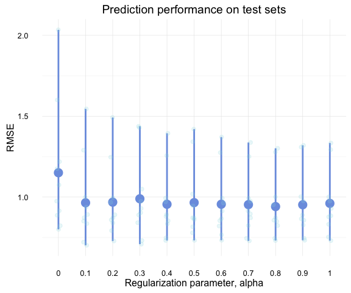

```r
# Fit models with `alpha` values ranging from 0 to 1, each to 100
# cross-validation samples:
pl <- pipelearner(d) %>%
  learn_models(cv.glmnet, cty ~ ., alpha = seq(0, 1, .1)) %>%
  learn_cvpairs(k = 10) %>%
  learn()

# Extract alpha and compute R-Squared
pl <- pl %>%
  mutate(alpha     = map_dbl(params, "alpha"),
         true      = map2(test, target, pull_from_resample),
         predicted = map2(fit, test, predict, s = "lambda.min"),
         rsquared  = map2_dbl(true, predicted, rmse))

# Plot
ggplot(pl, aes(factor(alpha), rsquared)) +
  stat_summary(fun.y = mean, fun.ymin = min, fun.ymax = max,
                 size = 1, colour = "#7c9ee1") +
  geom_jitter(width = .2, size = 2, alpha = .2, color = "#99dbe3") +
  ggtitle("Prediction performance on test sets") +
  labs(x = "Regularization parameter, alpha",
       y = "RMSE")
```

## Sign off

Thanks for reading and I hope this was useful for you.

For updates of recent blog posts, follow [@drsimonj](https://twitter.com/drsimonj) on Twitter, or email me at drsimonjackson@gmail.com to get in touch.

If you’d like the code that produced this blog, check out the [blogR GitHub repository](https://github.com/drsimonj/blogR).